# Final Project Prelimiary EDA

Xunyuan Sun & Jing Du

```r
library(DataComputing)
library(mosaic)
```

## Guiding Question

The population changes during the two years and what changes have occurred about the income and unemployment rate for each county or each state?

## Become acquainted with the data sources

1. Where did you find them? We found these data sources from kaggle.
2. Who collected/maintains them? The user name is MuonNeutrino
3. When & Why were they originally collected? These data sources was updated one years ago.
4. What does a case represent in each data source, and how many total cases are available? In acs2015_census_tract_data, each case for 2015 means each census tract in the U.S. In acs2017_census_tract_data, each case for 2017 means each census tract in the U.S.
5. What are some of the variables that you plan to use TractId, State, County, TotalPop, Men, Women, Hispanic, White, Black, Native, Asian, Pacific, Income

```r
Census_Tract_2015 <-
  read.csv("https://raw.githubusercontent.com/XYSunPSU/Final-Project/master/acs2015_census_tract_data.csv", header = T)

Census_Tract_2017 <-
  read.csv("https://raw.githubusercontent.com/XYSunPSU/Final-Project/master/acs2017_census_tract_data.csv", header = T)
```

```r
Census_Tract_2015
```

| CensusTract | State | County | TotalPop | Men | Women | Hispanic | White | Black | Native | Asian | Pacific | Citizen | Income | IncomeErr | IncomePerCap | IncomePerCapErr | Poverty | ChildPoverty | Professional | Service | Office | Construction | Production | Drive | Carpool | Transit | Walk | OtherTransp | WorkAtHome | … |
| --- | --- | --- | --- | --- | --- | --- | --- | --- | --- | --- | --- | --- | --- | --- | --- | --- | --- | --- | --- | --- | --- | --- | --- | --- | --- | --- | --- | --- | --- | --- |
| 1001020100 | Alabama | Autauga | 1948 | 940 | 1008 | 0.9 | 87.4 | 7.7 | 0.3 | 0.6 | 0.0 | 1503 | 61838 | 11900 | 25713 | 4548 | 8.1 | 8.4 | 34.7 | 17.0 | 21.3 | 11.9 | 15.2 | 90.2 | 4.8 | 0.0 | 0.5 | 2.3 | 2.1 | … |
| 1001020200 | Alabama | Autauga | 2156 | 1059 | 1097 | 0.8 | 40.4 | 53.3 | 0.0 | 2.3 | 0.0 | 1662 | 32303 | 13538 | 18021 | 2474 | 25.5 | 40.3 | 22.3 | 24.7 | 21.5 | 9.4 | 22.0 | 86.3 | 13.1 | 0.0 | 0.0 | 0.7 | 0.0 | … |
| 1001020300 | Alabama | Autauga | 2968 | 1364 | 1604 | 0.0 | 74.5 | 18.6 | 0.5 | 1.4 | 0.3 | 2335 | 44922 | 5629 | 20689 | 2817 | 12.7 | 19.7 | 31.4 | 24.9 | 22.1 | 9.2 | 12.4 | 94.8 | 2.8 | 0.0 | 0.0 | 0.0 | 2.5 | … |
| 1001020400 | Alabama | Autauga | 4423 | 2172 | 2251 | 10.5 | 82.8 | 3.7 | 1.6 | 0.0 | 0.0 | 3306 | 54329 | 7003 | 24125 | 2870 | 2.1 | 1.6 | 27.0 | 20.8 | 27.0 | 8.7 | 16.4 | 86.6 | 9.1 | 0.0 | 0.0 | 2.6 | 1.6 | … |
| 1001020500 | Alabama | Autauga | 10763 | 4922 | 5841 | 0.7 | 68.5 | 24.8 | 0.0 | 3.8 | 0.0 | 7666 | 51965 | 6935 | 27526 | 2813 | 11.4 | 17.5 | 49.6 | 14.2 | 18.2 | 2.1 | 15.8 | 88.0 | 10.5 | 0.0 | 0.0 | 0.6 | 0.9 | … |
| 1001020600 | Alabama | Autauga | 3851 | 1787 | 2064 | 13.1 | 72.9 | 11.9 | 0.0 | 0.0 | 0.0 | 2642 | 63092 | 9585 | 30480 | 7550 | 14.4 | 21.9 | 24.2 | 17.5 | 35.4 | 7.9 | 14.9 | 82.7 | 6.9 | 0.0 | 0.0 | 6.0 | 4.5 | … |
| 1001020700 | Alabama | Autauga | 2761 | 1210 | 1551 | 3.8 | 74.5 | 19.7 | 0.0 | 0.0 | 0.0 | 2060 | 34821 | 7867 | 20442 | 3245 | 28.9 | 41.9 | 19.5 | 29.6 | 25.3 | 10.1 | 15.5 | 92.4 | 7.6 | 0.0 | 0.0 | 0.0 | 0.0 | … |
| 1001020801 | Alabama | Autauga | 3187 | 1502 | 1685 | 1.3 | 84.0 | 10.7 | 3.1 | 0.0 | 0.0 | 2391 | 73728 | 2447 | 32813 | 4669 | 13.0 | 25.9 | 42.8 | 10.7 | 34.2 | 5.5 | 6.8 | 84.3 | 8.1 | 0.0 | 0.0 | 1.7 | 5.9 | … |
| 1001020802 | Alabama | Autauga | 10915 | 5486 | 5429 | 1.4 | 89.5 | 8.4 | 0.0 | 0.0 | 0.0 | 7778 | 60063 | 8602 | 24028 | 2233 | 13.9 | 18.3 | 31.5 | 17.5 | 26.1 | 7.8 | 17.1 | 90.1 | 8.6 | 0.0 | 0.0 | 0.0 | 1.3 | … |
| 1001020900 | Alabama | Autauga | 5668 | 2897 | 2771 | 0.4 | 85.5 | 12.1 | 0.0 | 0.3 | 0.0 | 4217 | 41287 | 7857 | 24710 | 4149 | 6.8 | 10.0 | 29.3 | 13.7 | 17.7 | 11.0 | 28.3 | 88.7 | 7.9 | 0.0 | 0.0 | 1.2 | 2.1 | … |

[output cut: 990 more lines]

```r
Census_Tract_2017
```

| TractId | State | County | TotalPop | Men | Women | Hispanic | White | Black | Native | Asian | Pacific | VotingAgeCitizen | Income | IncomeErr | IncomePerCap | IncomePerCapErr | Poverty | ChildPoverty | Professional | Service | Office | Construction | Production | Drive | Carpool | Transit | Walk | OtherTransp | WorkAtHome | … |
| --- | --- | --- | --- | --- | --- | --- | --- | --- | --- | --- | --- | --- | --- | --- | --- | --- | --- | --- | --- | --- | --- | --- | --- | --- | --- | --- | --- | --- | --- | --- |
| 1001020100 | Alabama | Autauga County | 1845 | 899 | 946 | 2.4 | 86.3 | 5.2 | 0.0 | 1.2 | 0.0 | 1407 | 67826 | 14560 | 33018 | 6294 | 10.7 | 20.8 | 38.5 | 15.6 | 22.8 | 10.8 | 12.4 | 94.2 | 3.3 | 0.0 | 0.5 | 0.0 | 2.1 | … |
| 1001020200 | Alabama | Autauga County | 2172 | 1167 | 1005 | 1.1 | 41.6 | 54.5 | 0.0 | 1.0 | 0.0 | 1652 | 41287 | 3819 | 18996 | 2453 | 22.4 | 35.8 | 30.5 | 24.9 | 22.9 | 6.3 | 15.4 | 90.5 | 9.1 | 0.0 | 0.0 | 0.5 | 0.0 | … |
| 1001020300 | Alabama | Autauga County | 3385 | 1533 | 1852 | 8.0 | 61.4 | 26.5 | 0.6 | 0.7 | 0.4 | 2480 | 46806 | 9496 | 21236 | 2562 | 14.7 | 21.1 | 27.9 | 19.4 | 33.3 | 9.9 | 9.6 | 88.3 | 8.4 | 0.0 | 1.0 | 0.8 | 1.5 | … |
| 1001020400 | Alabama | Autauga County | 4267 | 2001 | 2266 | 9.6 | 80.3 | 7.1 | 0.5 | 0.2 | 0.0 | 3257 | 55895 | 4369 | 28068 | 3190 | 2.3 | 1.7 | 29.0 | 16.6 | 25.8 | 9.1 | 19.5 | 82.3 | 11.2 | 0.0 | 1.5 | 2.9 | 2.1 | … |
| 1001020500 | Alabama | Autauga County | 9965 | 5054 | 4911 | 0.9 | 77.5 | 16.4 | 0.0 | 3.1 | 0.0 | 7229 | 68143 | 14424 | 36905 | 10706 | 12.2 | 17.9 | 48.8 | 13.8 | 20.5 | 3.5 | 13.4 | 86.9 | 11.2 | 0.0 | 0.8 | 0.3 | 0.7 | … |
| 1001020600 | Alabama | Autauga County | 3620 | 1765 | 1855 | 3.0 | 70.7 | 25.1 | 0.0 | 0.0 | 0.0 | 2687 | 44549 | 16126 | 27038 | 4427 | 13.6 | 20.2 | 25.2 | 24.6 | 29.0 | 8.1 | 13.1 | 83.0 | 4.8 | 0.0 | 0.7 | 3.5 | 8.0 | … |
| 1001020700 | Alabama | Autauga County | 3420 | 1459 | 1961 | 4.0 | 78.0 | 13.7 | 0.6 | 0.0 | 0.0 | 2538 | 41250 | 16811 | 19028 | 2587 | 27.0 | 27.7 | 25.4 | 35.0 | 21.6 | 5.6 | 12.4 | 89.0 | 11.0 | 0.0 | 0.0 | 0.0 | 0.0 | … |
| 1001020801 | Alabama | Autauga County | 2913 | 1495 | 1418 | 4.2 | 86.3 | 7.1 | 1.5 | 0.0 | 0.0 | 2163 | 80089 | 13397 | 36631 | 5174 | 12.0 | 25.1 | 46.0 | 9.1 | 30.6 | 8.3 | 6.0 | 89.5 | 4.6 | 0.0 | 0.0 | 0.7 | 5.2 | … |
| 1001020802 | Alabama | Autauga County | 11333 | 5488 | 5845 | 1.4 | 81.8 | 15.3 | 0.0 | 1.0 | 0.0 | 8248 | 64439 | 8677 | 26621 | 2187 | 14.7 | 21.8 | 36.8 | 20.2 | 19.6 | 9.3 | 14.0 | 89.1 | 8.7 | 0.0 | 0.0 | 0.0 | 2.2 | … |
| 1001020900 | Alabama | Autauga County | 6167 | 3111 | 3056 | 1.0 | 86.2 | 9.7 | 0.8 | 0.3 | 0.0 | 4710 | 49469 | 15517 | 26726 | 3839 | 9.4 | 13.2 | 32.3 | 12.7 | 20.1 | 6.4 | 28.6 | 77.2 | 11.9 | 0.0 | 0.0 | 5.0 | 5.9 | … |

[output cut: 990 more lines]

## Explore intuition related to research question

1. Create some informative plots and summary statistics

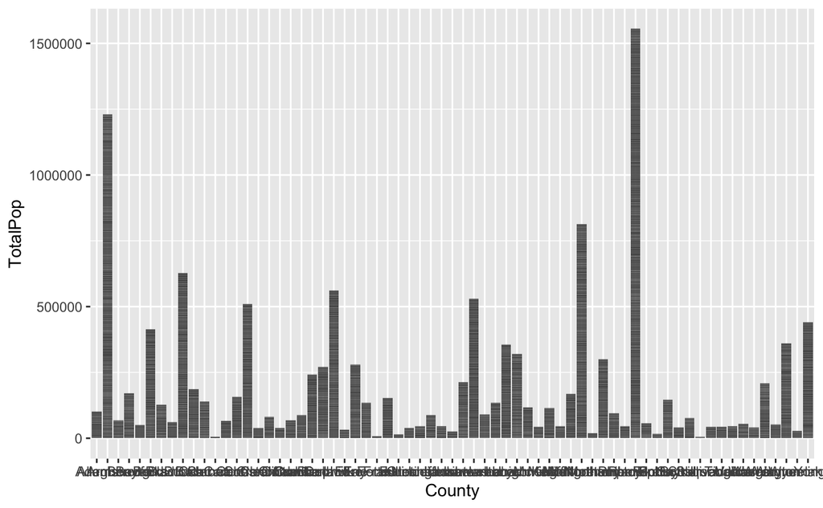

```r
graphdata <-
  Census_Tract_2015%>%
  filter(State == "Pennsylvania")

ggplot(data=graphdata,aes(x=County,y=TotalPop ))+geom_bar(stat='identity',position='stack', width=.9)
```

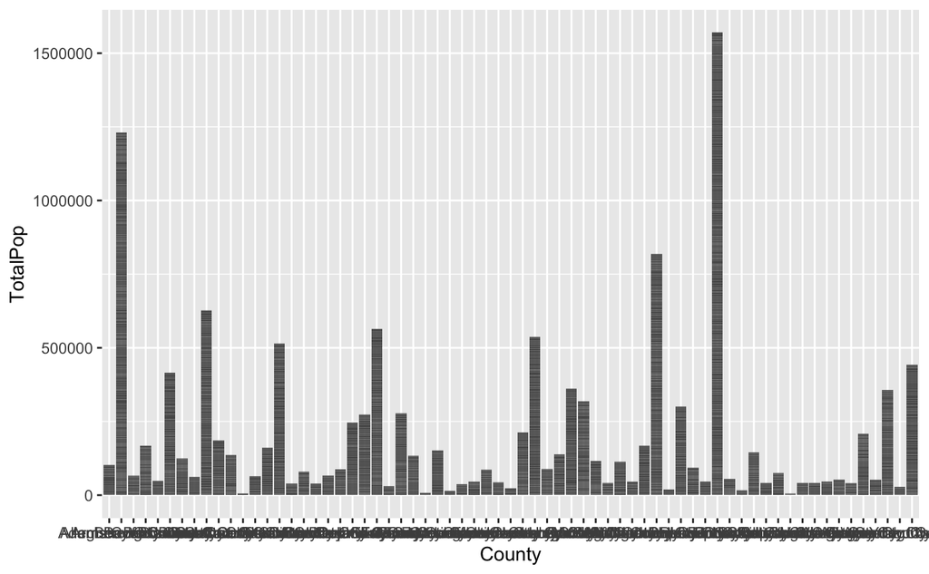

```r
graphdata <-
  Census_Tract_2017%>%
  filter(State == "Pennsylvania")

ggplot(data=graphdata,aes(x=County,y=TotalPop ))+geom_bar(stat='identity',position='stack', width=.9)
```

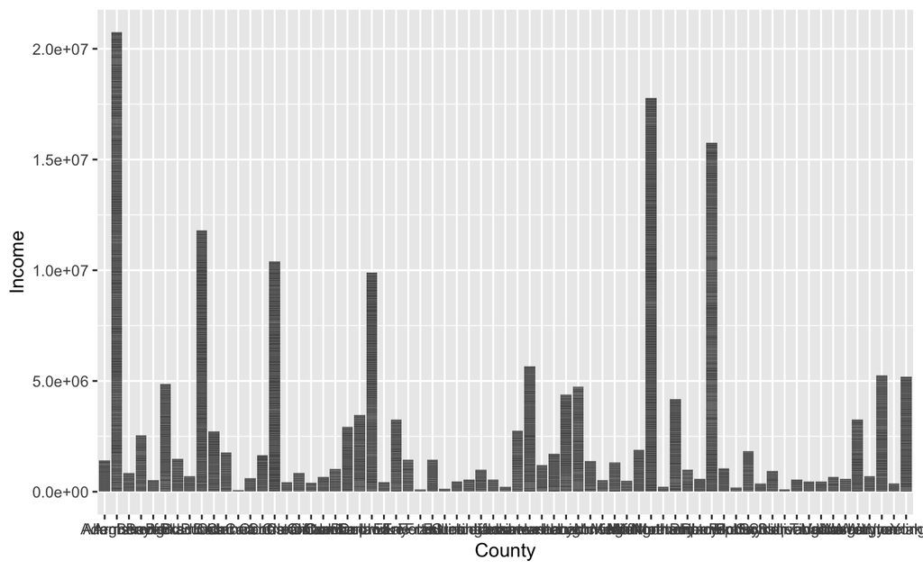

```r
incomedata <-
  Census_Tract_2015%>%
  filter(State == "Pennsylvania")

ggplot(data=incomedata,aes(x=County,y=Income ))+geom_bar(stat='identity',position='stack', width=.9)
```

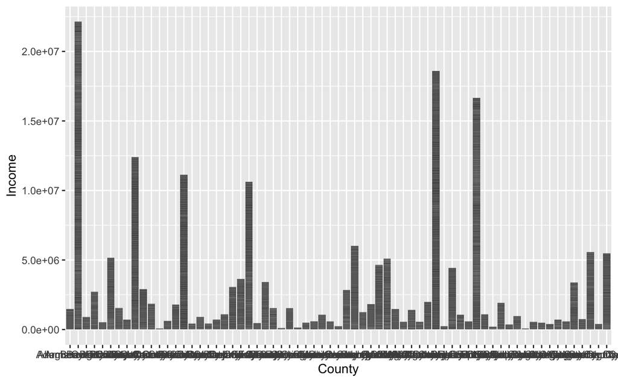

```r
incomedata2 <-
  Census_Tract_2017%>%
  filter(State == "Pennsylvania")

ggplot(data=incomedata2,aes(x=County,y=Income ))+geom_bar(stat='identity',position='stack', width=.9)
```

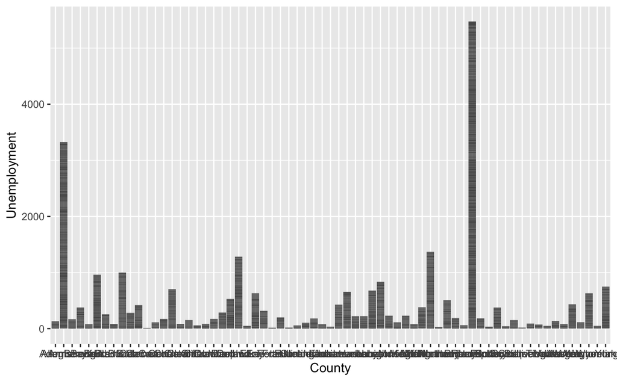

```r
UEdata <-
  Census_Tract_2015%>%
  filter(State == "Pennsylvania")

ggplot(data=UEdata,aes(x=County,y=Unemployment ))+geom_bar(stat='identity',position='stack', width=.9)
```

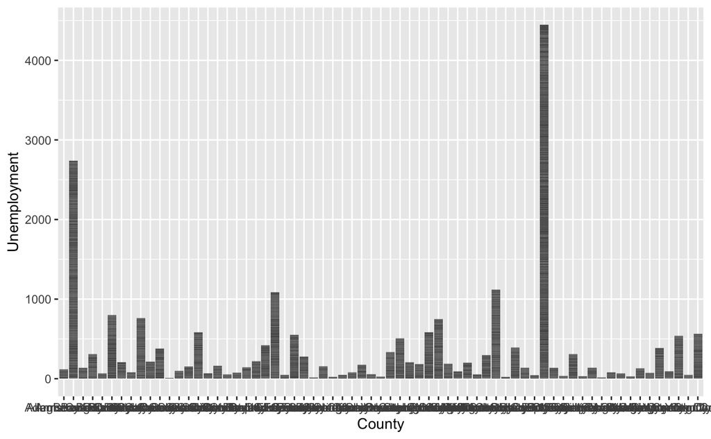

```r
UEdata2 <-
  Census_Tract_2017%>%
  filter(State == "Pennsylvania")

ggplot(data=UEdata2,aes(x=County,y=Unemployment ))+geom_bar(stat='identity',position='stack', width=.9)
```

2. Describe preliminary observations and intuition about the research question

I found that the population, income and unemployment rate of each county were similar in 2015 and 2017,But between different counties, their population, income and unemployment is different. So we want to study whether there is a relationship between population and income (per capita income), We are also interested in the relationship between ethnic distribution and income.

## Two or more data sources

1. acs2017_census_tract_data.csv
2. acs2015_census_tract_data.csv